# py_tensorflow_binaryclass_bondora_p2p_lending

### Binary Classification Model for Bondora P2P Lending Using Python and TensorFlow

### September 3, 2021

Template Credit: Adapted from a template made available by Dr. Jason Brownlee of Machine Learning Mastery. [https://machinelearningmastery.com/]

SUMMARY: This project aims to construct a predictive model using various machine learning algorithms and document the end-to-end steps using a template. The Bondora P2P Lending dataset is a binary classification situation where we attempt to predict one of the two possible outcomes.

INTRODUCTION: The Kaggle dataset owner retrieved this dataset from Bondora, a leading European peer-to-peer lending platform. The data comprises demographic and financial information of the borrowers with defaulted and non-defaulted loans between February 2009 and July 2021. For investors, “peer-to-peer lending” or “P2P” offers an attractive way to diversify portfolios and enhance long-term performance. However, to make effective decisions, investors want to minimize the risk of default of each lending decision and realize the return that compensates for the risk. Therefore, we will predict the default risk by focusing on the “DefaultDate” attribute as the target.

CONCLUSION: In this iteration, the TensorFlow model appeared to be a suitable algorithm for modeling this dataset.

Dataset Used: Kaggle Bondora P2P Lending Loan Data

Dataset ML Model: Binary classification with numerical and categorical attributes

Dataset Reference: https://www.kaggle.com/sid321axn/bondora-peer-to-peer-lending-loan-data

Dataset Attribute Description: https://www.bondora.com/en/public-reports

One potential source of performance benchmark: https://www.kaggle.com/sid321axn/bondora-peer-to-peer-lending-loan-data/code

Any predictive modeling machine learning project generally can be broken down into about six major tasks:

1. Prepare Environment
2. Summarize and Visualize Data
3. Pre-process Data
4. Train and Evaluate Models
5. Fine-tune and Improve Models
6. Finalize Model and Present Analysis

## Task 1 - Prepare Environment

```python
# Install the necessary packages for Colab
# !pip install python-dotenv PyMySQL
```

```python
# Retrieve the GPU information from Colab
gpu_info = !nvidia-smi
gpu_info = '\n'.join(gpu_info)
if gpu_info.find('failed') >= 0:
    print('Select the Runtime → "Change runtime type" menu to enable a GPU accelerator, ')
    print('and then re-execute this cell.')
else:
    print(gpu_info)
```

```
Tue Aug 24 19:04:11 2021
+-----------------------------------------------------------------------------+
| NVIDIA-SMI 470.57.02    Driver Version: 460.32.03    CUDA Version: 11.2     |
|-------------------------------+----------------------+----------------------+
| GPU  Name        Persistence-M| Bus-Id        Disp.A | Volatile Uncorr. ECC |
| Fan  Temp  Perf  Pwr:Usage/Cap|         Memory-Usage | GPU-Util  Compute M. |
|                               |                      |               MIG M. |
|===============================+======================+======================|
|   0  Tesla P100-PCIE...  Off  | 00000000:00:04.0 Off |                    0 |
| N/A   42C    P0    28W / 250W |      0MiB / 16280MiB |      0%      Default |
|                               |                      |                  N/A |
+-------------------------------+----------------------+----------------------+

+-----------------------------------------------------------------------------+
| Processes:                                                                  |
|  GPU   GI   CI        PID   Type   Process name                  GPU Memory |
|        ID   ID                                                   Usage      |
|=============================================================================|
|  No running processes found                                                 |
+-----------------------------------------------------------------------------+
```

```python
# Retrieve the memory configuration from Colab
from psutil import virtual_memory
ram_gb = virtual_memory().total / 1e9
print('Your runtime has {:.1f} gigabytes of available RAM\n'.format(ram_gb))

if ram_gb < 20:
    print('To enable a high-RAM runtime, select the Runtime → "Change runtime type"')
    print('menu, and then select High-RAM in the Runtime shape dropdown. Then, ')
    print('re-execute this cell.')
else:
    print('You are using a high-RAM runtime!')
```

```
Your runtime has 13.6 gigabytes of available RAM

To enable a high-RAM runtime, select the Runtime → "Change runtime type"
menu, and then select High-RAM in the Runtime shape dropdown. Then,
re-execute this cell.
```

```python
# Retrieve the CPU information
ncpu = !nproc
print("The number of available CPUs is:", ncpu[0])
```

```
The number of available CPUs is: 2
```

### 1.a) Load libraries and modules

```python
# Set the random seed number for reproducible results
RNG_SEED = 8
```

```python
import random
random.seed(RNG_SEED)
import numpy as np
np.random.seed(RNG_SEED)
import pandas as pd
import seaborn as sns
import matplotlib.pyplot as plt
import os
import sys
import math
from datetime import datetime
# import boto3
# from dotenv import load_dotenv
from sklearn import preprocessing
from sklearn.model_selection import train_test_split
from sklearn.model_selection import RepeatedKFold
from sklearn.metrics import classification_report
from sklearn.metrics import confusion_matrix
from sklearn.metrics import accuracy_score
from sklearn.metrics import roc_auc_score
from sklearn.pipeline import Pipeline as SKL_Pipeline
from sklearn import compose
from sklearn import impute
from imblearn.pipeline import Pipeline as IMB_Pipeline
from imblearn.over_sampling import SMOTE
from imblearn.under_sampling import RandomUnderSampler

import tensorflow as tf
tf.random.set_seed(RNG_SEED)
from tensorflow import keras
from tensorflow.keras.callbacks import ReduceLROnPlateau
```

### 1.b) Set up the controlling parameters and functions

```python
# Begin the timer for the script processing
start_time_script = datetime.now()

# Set up the number of CPU cores available for multi-thread processing
N_JOBS = 1

# Set up the flag to stop sending progress emails (setting to True will send status emails!)
NOTIFY_STATUS = False

# Set the percentage sizes for splitting the dataset
# VAL_SET_RATIO = 0.2
TEST_SET_RATIO = 0.1

# Set the number of folds for cross validation
N_FOLDS = 10
N_ITERATIONS = 1

# Set various default modeling parameters
DEFAULT_LOSS = 'binary_crossentropy'
DEFAULT_METRICS = [tf.keras.metrics.AUC()]
DEFAULT_OPTIMIZER = tf.keras.optimizers.Adam(learning_rate=0.001)
DEFAULT_INITIALIZER = tf.keras.initializers.RandomNormal(seed=RNG_SEED)
CLASSIFIER_ACTIVATION = 'sigmoid'
MAX_EPOCHS = 20
BATCH_SIZE = 32

# Define the labels to use for graphing the data
train_metric = "auc"
validation_metric = "val_auc"
train_loss = "loss"
validation_loss = "val_loss"

# Check the number of GPUs accessible through TensorFlow
print('Num GPUs Available:', len(tf.config.list_physical_devices('GPU')))

# Print out the TensorFlow version for confirmation
print('TensorFlow version:', tf.__version__)
```

```
Num GPUs Available: 1
TensorFlow version: 2.6.0
```

```python
# Set up the email notification function
def status_notify(msg_text):
    access_key = os.environ.get('SNS_ACCESS_KEY')
    secret_key = os.environ.get('SNS_SECRET_KEY')
    aws_region = os.environ.get('SNS_AWS_REGION')
    topic_arn = os.environ.get('SNS_TOPIC_ARN')
    if (access_key is None) or (secret_key is None) or (aws_region is None):
        sys.exit("Incomplete notification setup info. Script Processing Aborted!!!")
    sns = boto3.client('sns', aws_access_key_id=access_key, aws_secret_access_key=secret_key, region_name=aws_region)
    response = sns.publish(TopicArn=topic_arn, Message=msg_text)
    if response['ResponseMetadata']['HTTPStatusCode'] != 200 :
        print('Status notification not OK with HTTP status code:', response['ResponseMetadata']['HTTPStatusCode'])
```

```python
# Reset the random number generators
def reset_random(x=RNG_SEED):
    random.seed(x)
    np.random.seed(x)
    tf.random.set_seed(x)
```

```python
if NOTIFY_STATUS: status_notify("Task 1 - Prepare Environment has begun! " + datetime.now().strftime('%a %B %d, %Y %I:%M:%S %p'))
```

### 1.c) Load dataset

```python
dataset_path = 'https://dainesanalytics.com/datasets/kaggle-bondora-p2p-lending/LoanData_Bondora.csv'
df_dataset_import = pd.read_csv(dataset_path, index_col=False)

# Take a peek at the dataframe after import
print(df_dataset_import.head())
```

```
  ReportAsOfEOD  ... ActiveLateLastPaymentCategory
0    2021-07-20  ...                         31-60
1    2021-07-20  ...                          180+
2    2021-07-20  ...                          180+
3    2021-07-20  ...                          180+
4    2021-07-20  ...                          180+

[5 rows x 112 columns]
```

```python
df_dataset_import.info(verbose=True)
```

```
<class 'pandas.core.frame.DataFrame'>
RangeIndex: 179235 entries, 0 to 179234
Data columns (total 112 columns):
 #   Column                                  Dtype
---  ------                                  -----
 0   ReportAsOfEOD                           object
 1   LoanId                                  object
 2   LoanNumber                              int64
 3   ListedOnUTC                             object
 4   BiddingStartedOn                        object
 5   BidsPortfolioManager                    int64
 6   BidsApi                                 int64
 7   BidsManual                              float64
 8   UserName                                object
 9   NewCreditCustomer                       bool
```

[output cut: 104 more lines]

```python
print(df_dataset_import.describe())
```

```
         LoanNumber  ...  InterestAndPenaltyDebtServicingCost
count  1.792350e+05  ...                         76150.000000
mean   1.239306e+06  ...                           158.354431
std    6.610266e+05  ...                           366.688541
min    3.700000e+01  ...                             0.000000
25%    7.125380e+05  ...                             0.000000
50%    1.096557e+06  ...                             0.000000
75%    1.851458e+06  ...                           140.520000
max    2.313298e+06  ...                          5824.550000

[8 rows x 74 columns]
```

```python
print(df_dataset_import.isnull().sum())
print('Total number of NaN in the dataframe: ', df_dataset_import.isnull().sum().sum())
```

```
ReportAsOfEOD                               0
LoanId                                      0
LoanNumber                                  0
ListedOnUTC                                 0
BiddingStartedOn                            0
                                        ...
NrOfScheduledPayments                   66944
ReScheduledOn                          116191
PrincipalDebtServicingCost             103085
InterestAndPenaltyDebtServicingCost    103085
ActiveLateLastPaymentCategory           96967
Length: 112, dtype: int64
Total number of NaN in the dataframe:  5273975
```

### 1.d) Data Cleaning

```python
# Identify features with too many nulls to be useful
high_pct_null_features = []
total_records = df_dataset_import.shape[0]
for feature in df_dataset_import.columns:
    missing_records = df_dataset_import[feature].isnull().sum()
    missing_percentage = missing_records / total_records
    print('The feature %s has %d missing rows. Percentage: %g%%' % (feature, missing_records, missing_percentage*100))
    if missing_percentage >= 0.75:
        high_pct_null_features.append(feature)
print('Proposed list of features for removal:', high_pct_null_features)
```

```
The feature ReportAsOfEOD has 0 missing rows. Percentage: 0%
The feature LoanId has 0 missing rows. Percentage: 0%
The feature LoanNumber has 0 missing rows. Percentage: 0%
The feature ListedOnUTC has 0 missing rows. Percentage: 0%
The feature BiddingStartedOn has 0 missing rows. Percentage: 0%
The feature BidsPortfolioManager has 0 missing rows. Percentage: 0%
The feature BidsApi has 0 missing rows. Percentage: 0%
The feature BidsManual has 0 missing rows. Percentage: 0%
The feature UserName has 0 missing rows. Percentage: 0%
The feature NewCreditCustomer has 0 missing rows. Percentage: 0%
The feature LoanApplicationStartedDate has 0 missing rows. Percentage: 0%
The feature LoanDate has 0 missing rows. Percentage: 0%
The feature ContractEndDate has 76239 missing rows. Percentage: 42.5358%
The feature FirstPaymentDate has 0 missing rows. Percentage: 0%
The feature MaturityDate_Original has 0 missing rows. Percentage: 0%
The feature MaturityDate_Last has 0 missing rows. Percentage: 0%
The feature ApplicationSignedHour has 0 missing rows. Percentage: 0%
The feature ApplicationSignedWeekday has 0 missing rows. Percentage: 0%
The feature VerificationType has 50 missing rows. Percentage: 0.0278963%
The feature LanguageCode has 0 missing rows. Percentage: 0%
The feature Age has 0 missing rows. Percentage: 0%
The feature DateOfBirth has 179235 missing rows. Percentage: 100%
The feature Gender has 45 missing rows. Percentage: 0.0251067%
The feature Country has 0 missing rows. Percentage: 0%
The feature AppliedAmount has 0 missing rows. Percentage: 0%
The feature Amount has 0 missing rows. Percentage: 0%
The feature Interest has 0 missing rows. Percentage: 0%
The feature LoanDuration has 0 missing rows. Percentage: 0%
The feature MonthlyPayment has 6690 missing rows. Percentage: 3.73253%
The feature County has 179235 missing rows. Percentage: 100%
The feature City has 179235 missing rows. Percentage: 100%
The feature UseOfLoan has 0 missing rows. Percentage: 0%
The feature Education has 50 missing rows. Percentage: 0.0278963%
The feature MaritalStatus has 50 missing rows. Percentage: 0.0278963%
The feature NrOfDependants has 143635 missing rows. Percentage: 80.1378%
The feature EmploymentStatus has 202 missing rows. Percentage: 0.112701%
The feature EmploymentDurationCurrentEmployer has 1606 missing rows. Percentage: 0.89603%
The feature EmploymentPosition has 179235 missing rows. Percentage: 100%
The feature WorkExperience has 142713 missing rows. Percentage: 79.6234%
The feature OccupationArea has 91 missing rows. Percentage: 0.0507713%
```

[output cut: 58 more lines]

```
The feature NoOfPreviousLoansBeforeLoan has 9 missing rows. Percentage: 0.00502134%
The feature AmountOfPreviousLoansBeforeLoan has 9 missing rows. Percentage: 0.00502134%
The feature PreviousRepaymentsBeforeLoan has 62386 missing rows. Percentage: 34.8068%
The feature PreviousEarlyRepaymentsBefoleLoan has 120350 missing rows. Percentage: 67.1465%
The feature PreviousEarlyRepaymentsCountBeforeLoan has 9 missing rows. Percentage: 0.00502134%
The feature GracePeriodStart has 137350 missing rows. Percentage: 76.6312%
The feature GracePeriodEnd has 137350 missing rows. Percentage: 76.6312%
The feature NextPaymentDate has 113614 missing rows. Percentage: 63.3883%
The feature NextPaymentNr has 66944 missing rows. Percentage: 37.3498%
The feature NrOfScheduledPayments has 66944 missing rows. Percentage: 37.3498%
The feature ReScheduledOn has 116191 missing rows. Percentage: 64.8261%
The feature PrincipalDebtServicingCost has 103085 missing rows. Percentage: 57.5139%
The feature InterestAndPenaltyDebtServicingCost has 103085 missing rows. Percentage: 57.5139%
The feature ActiveLateLastPaymentCategory has 96967 missing rows. Percentage: 54.1005%
Proposed list of features for removal: ['DateOfBirth', 'County', 'City', 'NrOfDependants', 'EmploymentPosition', 'WorkExperience', 'EL_V0', 'Rating_V0', 'EL_V1', 'Rating_V1', 'Rating_V2', 'CreditScoreEsEquifaxRisk', 'CreditScoreFiAsiakasTietoRiskGrade', 'GracePeriodStart', 'GracePeriodEnd']
```

```python
# Identify more non-essential features to remove
non_essential_features = ['ReportAsOfEOD','LoanId','LoanNumber','ListedOnUTC','BiddingStartedOn',
                          'BidsPortfolioManager','BidsApi','BidsManual','UserName','LoanApplicationStartedDate',
                          'LoanDate','ContractEndDate','FirstPaymentDate','MaturityDate_Original','MaturityDate_Last',
                          'ApplicationSignedHour','ApplicationSignedWeekday','LanguageCode','Country',
                          'UseOfLoan','MaritalStatus','EmploymentStatus','OccupationArea','MonthlyPaymentDay',
                          'ActiveScheduleFirstPaymentReached','PlannedPrincipalTillDate','PlannedInterestTillDate','LastPaymentOn',
                          'DebtOccuredOn','DebtOccuredOnForSecondary','ModelVersion','EL_V0','Rating_V0',
                          'EL_V1','Rating_V1','Rating_V2','CreditScoreEsMicroL','CreditScoreEeMini',
                          'PrincipalPaymentsMade','InterestAndPenaltyWriteOffs','PrincipalBalance','InterestAndPenaltyBalance',
                          'NextPaymentDate','NextPaymentNr','NrOfScheduledPayments','ReScheduledOn']

# Identify post-mortem features induced by default
post_mortem_features = ['CurrentDebtDaysPrimary','DebtOccuredOn','CurrentDebtDaysSecondary','DebtOccuredOnForSecondary',
                        'PrincipalOverdueBySchedule','PlannedPrincipalPostDefault','PlannedInterestPostDefault',
                        'EAD1','EAD2','PrincipalRecovery','InterestRecovery','RecoveryStage',
                        'StageActiveSince','ActiveLateCategory','WorseLateCategory','PrincipalWriteOffs',
                        'PrincipalDebtServicingCost','InterestAndPenaltyDebtServicingCost',
                        'InterestAndPenaltyWriteOffs','ActiveLateLastPaymentCategory']

final_features_removal = non_essential_features + high_pct_null_features + post_mortem_features
print('Final list of features to remove:', final_features_removal)
```

```
Final list of features to remove: ['ReportAsOfEOD', 'LoanId', 'LoanNumber', 'ListedOnUTC', 'BiddingStartedOn', 'BidsPortfolioManager', 'BidsApi', 'BidsManual', 'UserName', 'LoanApplicationStartedDate', 'LoanDate', 'ContractEndDate', 'FirstPaymentDate', 'MaturityDate_Original', 'MaturityDate_Last', '…
```

```python
# Drop non-essential features
df_dataset_import.drop(columns=final_features_removal, inplace=True)

# Convert columns from one data type to another
df_dataset_import['VerificationType'].fillna(0, inplace=True)
df_dataset_import['VerificationType'] = df_dataset_import['VerificationType'].astype('category')
df_dataset_import['Gender'].fillna(2, inplace=True)
df_dataset_import['Gender'] = df_dataset_import['Gender'].astype('category')
df_dataset_import['Education'].fillna(-1, inplace=True)
df_dataset_import['Education'] = df_dataset_import['Education'].astype('category')
df_dataset_import['EmploymentDurationCurrentEmployer'] = df_dataset_import['EmploymentDurationCurrentEmployer'].astype('category')
df_dataset_import['HomeOwnershipType'].fillna(-1, inplace=True)
df_dataset_import['HomeOwnershipType'] = df_dataset_import['HomeOwnershipType'].astype('category')
df_dataset_import['Rating'] = df_dataset_import['Rating'].astype('category')
df_dataset_import['Status'] = df_dataset_import['Status'].astype('category')

# Convert the DefaultDate feature into the 0/1 target variable
df_dataset_import['DefaultDate'].fillna('UNKNOWN', inplace=True)
def reclass_somecol(target):
    if target == 'UNKNOWN': return 0
    else: return 1
df_dataset_import['target'] = df_dataset_import['DefaultDate'].apply(reclass_somecol)
df_dataset_import.drop(columns=['DefaultDate'], inplace=True)

# Take a peek at the dataframe after cleaning
print(df_dataset_import.head())
```

```
   NewCreditCustomer  ... target
0              False  ...      1
1              False  ...      1
2               True  ...      1
3               True  ...      1
4               True  ...      1

[5 rows x 39 columns]
```

```python
df_dataset_import.info(verbose=True)
```

```
<class 'pandas.core.frame.DataFrame'>
RangeIndex: 179235 entries, 0 to 179234
Data columns (total 39 columns):
 #   Column                                  Non-Null Count   Dtype
---  ------                                  --------------   -----
 0   NewCreditCustomer                       179235 non-null  bool
 1   VerificationType                        179235 non-null  category
 2   Age                                     179235 non-null  int64
 3   Gender                                  179235 non-null  category
 4   AppliedAmount                           179235 non-null  float64
 5   Amount                                  179235 non-null  float64
 6   Interest                                179235 non-null  float64
 7   LoanDuration                            179235 non-null  int64
 8   MonthlyPayment                          172545 non-null  float64
 9   Education                               179235 non-null  category
```

[output cut: 31 more lines]

```python
print(df_dataset_import.describe())
```

```
                 Age  ...         target
count  179235.000000  ...  179235.000000
mean       40.389137  ...       0.398449
std        12.359547  ...       0.489580
min         0.000000  ...       0.000000
25%        31.000000  ...       0.000000
50%        39.000000  ...       0.000000
75%        49.000000  ...       1.000000
max        77.000000  ...       1.000000

[8 rows x 30 columns]
```

```python
print(df_dataset_import.isnull().sum())
print('Total number of NaN in the dataframe: ', df_dataset_import.isnull().sum().sum())
```

```
NewCreditCustomer                              0
VerificationType                               0
Age                                            0
Gender                                         0
AppliedAmount                                  0
Amount                                         0
Interest                                       0
LoanDuration                                   0
MonthlyPayment                              6690
Education                                      0
EmploymentDurationCurrentEmployer           1606
HomeOwnershipType                              0
IncomeFromPrincipalEmployer                    0
IncomeFromPension                              0
IncomeFromFamilyAllowance                      0
IncomeFromSocialWelfare                        0
IncomeFromLeavePay                             0
IncomeFromChildSupport                         0
IncomeOther                                    0
IncomeTotal                                    0
ExistingLiabilities                            0
LiabilitiesTotal                               0
RefinanceLiabilities                           0
DebtToIncome                                  50
FreeCash                                      50
ExpectedLoss                                2639
LossGivenDefault                            2639
ExpectedReturn                              2639
ProbabilityOfDefault                        2639
Rating                                      2733
Status                                         0
Restructured                                   0
InterestAndPenaltyPaymentsMade                 0
NoOfPreviousLoansBeforeLoan                    9
AmountOfPreviousLoansBeforeLoan                9
PreviousRepaymentsBeforeLoan               62386
PreviousEarlyRepaymentsBefoleLoan         120350
PreviousEarlyRepaymentsCountBeforeLoan         9
target                                         0
dtype: int64
Total number of NaN in the dataframe:  204448
```

### 1.e) Splitting Data into Sets

```python
# Use variable total_column_count to hold the number of columns in the dataframe
total_column_count = len(df_dataset_import.columns)

# Set up variable total_feature_count for the total number of attribute columns
total_feature_count = total_column_count-1
```

```python
# Standardize the class column to the name of target
# df_dataset_import = df_dataset_import.rename(columns={'not.fully.paid':'target'})
```

```python
# Split the data further into training, validation, and test datasets
df_train, df_test = train_test_split(df_dataset_import, test_size=TEST_SET_RATIO, stratify=df_dataset_import['target'], random_state=RNG_SEED)

# We create attribute-only and target-only datasets (df_features_train and df_target_train)
# for various visualization and cleaning/transformation operations
df_target_train = df_train['target']
df_features_train = df_train.drop(['target'], axis=1)

print("df_dataset_import.shape: {} df_train.shape: {} df_test.shape: {}".format(df_dataset_import.shape, df_train.shape,df_test.shape))
print("df_features_train.shape: {} df_target_train.shape: {}".format(df_features_train.shape, df_target_train.shape))
```

```
df_dataset_import.shape: (179235, 39) df_train.shape: (161311, 39) df_test.shape: (17924, 39)
df_features_train.shape: (161311, 38) df_target_train.shape: (161311,)
```

### 1.f) Set up the parameters for data visualization

```python
# Set up the number of row and columns for visualization display. display_rows * display_columns should be >= total_feature_count
display_columns = 4
if total_feature_count % display_columns == 0 :
    display_rows = total_feature_count // display_columns
else :
    display_rows = (total_feature_count // display_columns) + 1

# Set figure width to display the data visualization plots
fig_size = plt.rcParams["figure.figsize"]
fig_size[0] = display_columns * 4
fig_size[1] = display_rows * 4
plt.rcParams["figure.figsize"] = fig_size
```

```python
if NOTIFY_STATUS: status_notify("Task 1 - Prepare Environment completed! "+datetime.now().strftime('%a %B %d, %Y %I:%M:%S %p'))
```

## Task 2 - Summarize and Visualize Data

```python
if NOTIFY_STATUS: status_notify("Task 2 - Summarize and Visualize Data has begun! "+datetime.now().strftime('%a %B %d, %Y %I:%M:%S %p'))
```

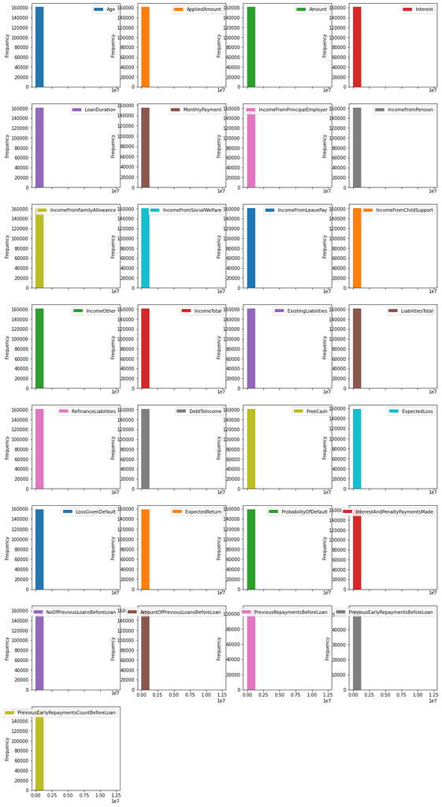

```python
# Histograms for each attribute
df_features_train.plot(kind='hist', subplots=True, layout=(display_rows, display_columns))
plt.show()
```

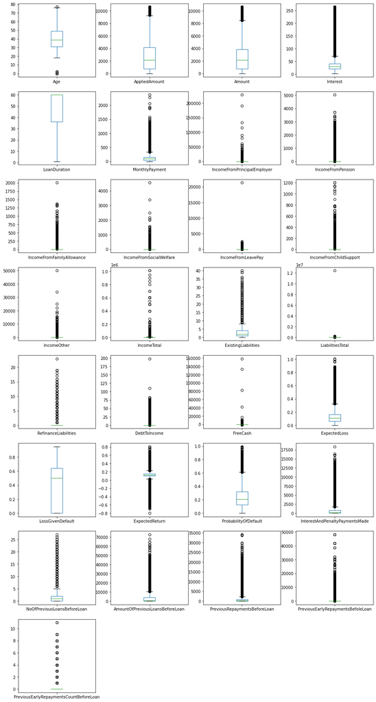

```python
# Box and Whisker plot for each attribute
df_features_train.plot(kind='box', subplots=True, layout=(display_rows, display_columns))
plt.show()
```

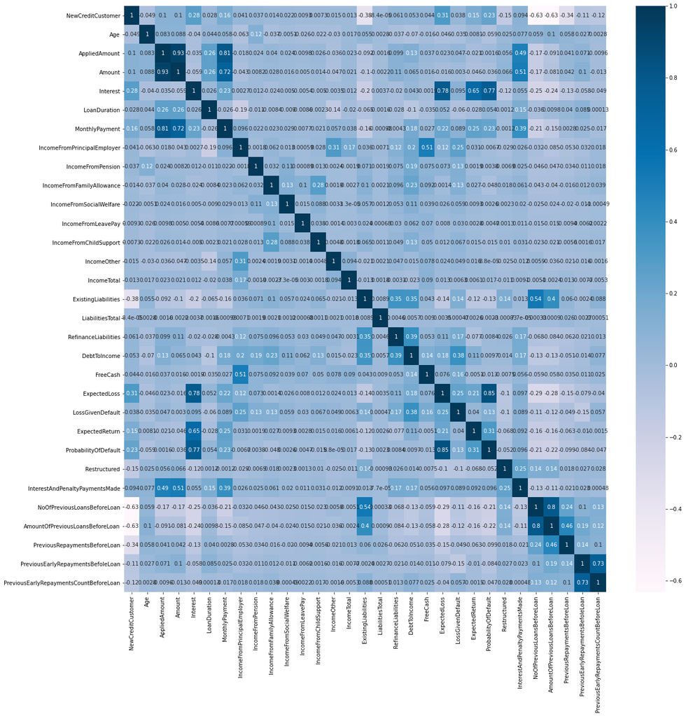

```python
# Correlation matrix
fig = plt.figure(figsize=(20, 20))
correlations = df_features_train.corr(method='pearson')
sns.heatmap(correlations, annot=True, cmap=plt.cm.PuBu)
plt.show()
```

```python
if NOTIFY_STATUS: status_notify("Task 2 - Summarize and Visualize Data completed! "+datetime.now().strftime('%a %B %d, %Y %I:%M:%S %p'))
```

## Task 3 - Pre-process Data

```python
if NOTIFY_STATUS: status_notify("Task 3 - Pre-process Data has begun! "+datetime.now().strftime('%a %B %d, %Y %I:%M:%S %p'))
```

### 3.a) Feature Scaling and Data Pre-Processing

```python
# Compose pipeline for the numerical and categorical features (Block #1 of 2)
numeric_columns = df_features_train.select_dtypes(include=['int64','float64']).columns
numeric_transformer = SKL_Pipeline(steps=[
    ('imputer', impute.SimpleImputer(strategy='constant', fill_value=0)),
    ('scaler', preprocessing.MinMaxScaler())
])
categorical_columns = df_features_train.select_dtypes(include=['object','bool','category']).columns
categorical_transformer = SKL_Pipeline(steps=[
    ('imputer', impute.SimpleImputer(strategy='constant', fill_value='UKNOWN')),
    ('onehot', preprocessing.OneHotEncoder(sparse=False, handle_unknown='ignore'))
])

print("Number of numerical columns:", len(numeric_columns))
print("Number of categorical columns:", len(categorical_columns))
print("Total number of columns in the feature dataframe:", df_features_train.shape[1])
```

```
Number of numerical columns: 29
Number of categorical columns: 9
Total number of columns in the feature dataframe: 38
```

```python
# Compose pipeline for the numerical and categorical features (Block #2 of 2)
preprocessor = compose.ColumnTransformer(transformers=[
    ('num', numeric_transformer, numeric_columns),
    ('cat', categorical_transformer, categorical_columns)
])

# Display the shapes of the training dataset for final inspection
array_features_train = preprocessor.fit_transform(df_features_train)
print("Transformed features from df_features_train.shape: {} to array_features_train.shape: {}".format(df_features_train.shape, array_features_train.shape))
```

```
Transformed features from df_features_train.shape: (161311, 38) to array_features_train.shape: (161311, 82)
```

### 3.b) Training Data Balancing

```python
# Not applicable for this iteration of the project
```

### 3.c) Feature Selection

```python
# Not applicable for this iteration of the project
```

### 3.d) Display the Final Datasets for Model-Building

```python
# Finalize the training and validation datasets for the modeling activities
# array_features_train = df_features_train.to_numpy()
array_target_train = df_target_train.ravel()
print("array_features_train.shape: {} array_target_train.shape: {}".format(array_features_train.shape, array_target_train.shape))
```

```
array_features_train.shape: (161311, 82) array_target_train.shape: (161311,)
```

```python
if NOTIFY_STATUS: status_notify("Task 3 - Pre-process Data completed! "+datetime.now().strftime('%a %B %d, %Y %I:%M:%S %p'))
```

## Task 4 - Train and Evaluate Models

```python
if NOTIFY_STATUS: status_notify("Task 4 - Train and Evaluate Models has begun! "+datetime.now().strftime('%a %B %d, %Y %I:%M:%S %p'))
```

```python
# Define the baseline model for benchmarking
def create_nn_model(input_param=array_features_train.shape[1], layer1_nodes=4096, layer2_nodes=2048, layer3_nodes=1024, layer4_nodes=2014, layer5_nodes=512,
                    layer1_dropout=0.25, layer2_dropout=0.25, layer3_dropout=0.25, layer4_dropout=0.25, layer5_dropout=0.25,
                    init_param=DEFAULT_INITIALIZER, classifier_activation=CLASSIFIER_ACTIVATION,
                    loss_param=DEFAULT_LOSS, opt_param=DEFAULT_OPTIMIZER, metrics_param=DEFAULT_METRICS):
    nn_model = keras.Sequential([
        keras.layers.Dense(layer1_nodes, input_shape=(input_param,), activation='relu', kernel_initializer=init_param),
        keras.layers.Dropout(layer1_dropout),
        keras.layers.Dense(layer2_nodes, activation='relu', kernel_initializer=init_param),
        keras.layers.Dropout(layer2_dropout),
        keras.layers.Dense(layer3_nodes, activation='relu', kernel_initializer=init_param),
        keras.layers.Dropout(layer3_dropout),
        keras.layers.Dense(layer4_nodes, activation='relu', kernel_initializer=init_param),
        keras.layers.Dropout(layer4_dropout),
        keras.layers.Dense(layer5_nodes, activation='relu', kernel_initializer=init_param),
        keras.layers.Dropout(layer5_dropout),
        keras.layers.Dense(1, activation=classifier_activation)
    ])
    nn_model.compile(loss=loss_param, optimizer=opt_param, metrics=metrics_param)
    return nn_model
```

```python
# Initialize the default model and get a baseline result
start_time_module = datetime.now()
learning_rate_reduction = ReduceLROnPlateau(monitor='val_accuracy', patience=8, verbose=1, factor=0.5, min_lr=0.000001)
results = list()
iteration = 0
cv = RepeatedKFold(n_splits=N_FOLDS, n_repeats=N_ITERATIONS, random_state=RNG_SEED)
for train_ix, val_ix in cv.split(array_features_train):
    feature_train, feature_validation = array_features_train[train_ix], array_features_train[val_ix]
    target_train, target_validation = array_target_train[train_ix], array_target_train[val_ix]
    reset_random()
    baseline_model = create_nn_model()
    baseline_model.fit(feature_train, target_train, epochs=MAX_EPOCHS, batch_size=BATCH_SIZE, verbose=0)
    model_metric = baseline_model.evaluate(feature_validation, target_validation, verbose=1)[1]
    iteration = iteration + 1
    print('Score from iteration %d >>> %.4f' % (iteration, model_metric))
    results.append(model_metric)
validation_score = np.mean(results)
validation_variance = np.std(results)
print('Average model scorer from all iterations: %.4f (%.4f)' % (validation_score, validation_variance))
print('Total time for model fitting and cross validating:', (datetime.now() - start_time_module))
```

```
Score from iteration 1 >>> 0.9712
Score from iteration 2 >>> 0.9740
Score from iteration 3 >>> 0.9736
Score from iteration 4 >>> 0.9737
Score from iteration 5 >>> 0.9731
Score from iteration 6 >>> 0.9720
Score from iteration 7 >>> 0.9717
Score from iteration 8 >>> 0.9710
Score from iteration 9 >>> 0.9725
Score from iteration 10 >>> 0.9736
Average model scorer from all iterations: 0.9726 (0.0010)
Total time for model fitting and cross validating: 0:48:43.221978
```

```python
if NOTIFY_STATUS: status_notify("Task 4 - Train and Evaluate Models completed! "+datetime.now().strftime('%a %B %d, %Y %I:%M:%S %p'))
```

```python
if NOTIFY_STATUS: status_notify("Task 5 - Finalize Model and Present Analysis has begun! "+datetime.now().strftime('%a %B %d, %Y %I:%M:%S %p'))
```

### 6.a) Train the Final Model

```python
learning_rate_reduction = ReduceLROnPlateau(monitor='auc', patience=5, verbose=1, factor=0.5, min_lr=0.000001)
final_model = create_nn_model()
final_model.fit(array_features_train, array_target_train, epochs=MAX_EPOCHS, batch_size=BATCH_SIZE, callbacks=[learning_rate_reduction], verbose=0)
final_model.summary()
```

```
Epoch 00006: ReduceLROnPlateau reducing learning rate to 0.0005000000237487257.

Epoch 00011: ReduceLROnPlateau reducing learning rate to 0.0002500000118743628.

Epoch 00016: ReduceLROnPlateau reducing learning rate to 0.0001250000059371814.
Model: "sequential_10"
_________________________________________________________________
Layer (type)                 Output Shape              Param #
=================================================================
dense_60 (Dense)             (None, 4096)              339968
_________________________________________________________________
dropout_50 (Dropout)         (None, 4096)              0
_________________________________________________________________
dense_61 (Dense)             (None, 2048)              8390656
_________________________________________________________________
dropout_51 (Dropout)         (None, 2048)              0
_________________________________________________________________
dense_62 (Dense)             (None, 1024)              2098176
_________________________________________________________________
dropout_52 (Dropout)         (None, 1024)              0
_________________________________________________________________
dense_63 (Dense)             (None, 2014)              2064350
_________________________________________________________________
dropout_53 (Dropout)         (None, 2014)              0
_________________________________________________________________
dense_64 (Dense)             (None, 512)               1031680
_________________________________________________________________
dropout_54 (Dropout)         (None, 512)               0
_________________________________________________________________
dense_65 (Dense)             (None, 1)                 513
=================================================================
Total params: 13,925,343
Trainable params: 13,925,343
Non-trainable params: 0
_________________________________________________________________
```

### 6.b) Load Test Dataset and Make Predictions

```python
# We create attribute-only and target-only datasets
df_target_test = df_test['target']
df_features_test = df_test.drop(['target'], axis=1)

print("df_features_test.shape: {} df_target_test.shape: {}".format(df_features_test.shape, df_target_test.shape))
```

```
df_features_test.shape: (17924, 38) df_target_test.shape: (17924,)
```

```python
# Finalize the test dataset for the modeling testing
array_features_test = preprocessor.transform(df_features_test)
print("Transformed features from df_features_test.shape: {} to array_features_test.shape: {}".format(df_features_test.shape, array_features_test.shape))
```

```
Transformed features from df_features_test.shape: (17924, 38) to array_features_test.shape: (17924, 82)
```

```python
# Finalize the test dataset for the testing activities
array_target_test = df_target_test.ravel()
print("array_features_test.shape: {} array_target_test.shape: {}".format(array_features_test.shape, array_target_test.shape))
```

```
array_features_test.shape: (17924, 82) array_target_test.shape: (17924,)
```

```python
# Make batched predictions
test_predictions = (final_model.predict(array_features_test) > 0.5).astype("int32").ravel()
print(test_predictions)
```

```
[1 1 1 ... 0 0 1]
```

```python
print('Accuracy Score:', accuracy_score(array_target_test, test_predictions))
print('ROC/AUC Score:', roc_auc_score(array_target_test, test_predictions))
print(confusion_matrix(array_target_test, test_predictions))
print(classification_report(array_target_test, test_predictions))
```

```
Accuracy Score: 0.913579558134345
ROC/AUC Score: 0.9075577568659008
[[10105   677]
 [  872  6270]]
              precision    recall  f1-score   support

           0       0.92      0.94      0.93     10782
           1       0.90      0.88      0.89      7142

    accuracy                           0.91     17924
   macro avg       0.91      0.91      0.91     17924
weighted avg       0.91      0.91      0.91     17924
```

```python
if NOTIFY_STATUS: status_notify("Task 5 - Finalize Model and Present Analysis completed! "+datetime.now().strftime('%a %B %d, %Y %I:%M:%S %p'))
```

```python
print ('Total time for the script:',(datetime.now() - start_time_script))
```

```
Total time for the script: 0:58:58.599387
```